# Transnational Family Migration and Loneliness Among Older Filipinos

First-Difference + IPW Analysis with Mechanism and Exploratory Moderation

Author

Jem Marie Nario

Published

April 13, 2026

# 1 Overview and Analytic Strategy

This document presents the full analysis for **“Transnational Family Migration and Loneliness Among Older Filipinos”** using the Longitudinal Study of Aging and Health in the Philippines (LSAHP), Waves 1 and 2.

## 1.1 Three-Tier Analytic Structure

The analysis is organised into three tiers reflecting different levels of causal identification and available sample size.

**Tier 2 — Associational / Mechanism (H2, n = 3,075).** Among respondents with non-co-resident children, changes in contact satisfaction and contact frequency are added to the FD model. These estimates identify within-person associations between communication quality and loneliness change, net of transnational transition. Reverse causality (loneliness reducing satisfaction) cannot be fully ruled out; findings are interpreted as evidence of mechanism rather than strict causal effects.

**Tier 3 — Exploratory (H3 + H4, n = 395).** Distance models are restricted to respondents with recorded destination countries in both waves. Crucially, this subsample consists **entirely of households that were already transnational at Wave 1 and remained so at Wave 2** — there are zero enterers in this subsample. The distance analysis therefore does not identify the entry effect; instead it asks: *among already-transnational households, does a child moving farther away increase parental loneliness, and does contact satisfaction buffer this?* This is a distinct and meaningful question, but must be clearly distinguished from the Tier 1 causal claim.

## 1.2 Key Missingness Facts

[output not shown]

The 92% missingness on distance is structural: destination country codes are only recorded when a child is abroad at both waves with a valid country code entered by the interviewer. The distance subsample is highly selected and findings must be treated as preliminary.

# 2 Setup

# 3 Load Data

```r
# Remove only data objects, not helper functions
rm(list = ls()[!ls() %in% c("LMUGreen", "theme_lmu", "save_plot")])

library(haven)

lsahp1 <- read_dta(
  "C:/Users/jemma/Downloads/LSAHP-Baseline-Data-STATA/LSAHP Baseline Data (STATA)/LSAHP1.dta"
)

lsahp2 <- read_dta(
  "H:/My Drive/UPPI_RUG/UPPI_RUG_DLSU/LSAHP W2 Transnational households and loneliness (Jem, 202602)/LSAHP W2 Transnational households and loneliness (Jem).dta"
)

cat("Wave 1 n =", nrow(lsahp1), "\n")
```

```
Wave 1 n = 5985
```

```r
cat("Wave 2 n =", nrow(lsahp2), "\n")
```

```
Wave 2 n = 5985
```

# 4 Wave 1 Variables

## 4.1 ID

```r
lsahp_w1 <- lsahp1 |> dplyr::mutate(id = P1ID1)
```

## 4.2 Outcomes

```r
# Binary: 1 = often lonely (frequent loneliness threshold)
lsahp_w1 <- lsahp_w1 |>
  dplyr::mutate(
    lonely_w1 = dplyr::case_when(
      P1SD1_06 == 3          ~ 1,
      P1SD1_06 %in% c(1, 2) ~ 0,
      TRUE                   ~ NA_real_
    )
  )

# 3-item continuous scale (0-4): mean of companionship, left out, isolated
# Wave 1 uses same 0-4 response categories as Wave 2 — confirmed comparable
lsahp_w1 <- lsahp_w1 |>
  dplyr::mutate(
    lonely_3item = dplyr::if_else(
      rowSums(dplyr::across(c(P1SH9_1, P1SH9_2, P1SH9_3),
                            ~ is.na(.x))) == 0,
      rowMeans(dplyr::across(c(P1SH9_1, P1SH9_2, P1SH9_3))),
      NA_real_
    )
  )

cat("Wave 1 lonely_w1:\n")
```

```
Wave 1 lonely_w1:
```

```r
table(lsahp_w1$lonely_w1, useNA = "ifany")
```

```
   0    1 <NA>
4795  414  776
```

```r
cat("\nWave 1 lonely_3item summary:\n")
```

```
Wave 1 lonely_3item summary:
```

```r
summary(lsahp_w1$lonely_3item)
```

```
   Min. 1st Qu.  Median    Mean 3rd Qu.    Max.    NA's
 0.0000  0.3333  1.0000  0.9453  1.3333  4.0000     775
```

## 4.3 Exposure: Transnational Household

```r
lsahp_w1 <- lsahp_w1 |>
  dplyr::mutate(
    child_abroad = dplyr::if_else(
      rowSums(dplyr::across(dplyr::starts_with("P1HH39_"),
                            ~ as.numeric(.x == 6)),
              na.rm = TRUE) > 0, 1L, 0L),

    # CORRECT: use P1HH42_* for child-specific OFW status
    child_ofw = dplyr::if_else(
      rowSums(dplyr::across(dplyr::starts_with("P1HH42_"),
                            ~ as.numeric(.x == 1)),
              na.rm = TRUE) > 0, 1L, 0L),

    transnational_hh = dplyr::if_else(
      child_abroad == 1L | child_ofw == 1L, 1L, 0L)
  )

cat("Wave 1 transnational_hh:\n")
```

```
Wave 1 transnational_hh:
```

```r
table(lsahp_w1$transnational_hh, useNA = "ifany")
```

```
   0    1
4795 1190
```

## 4.4 Mediators

```r
# Contact frequency: minimum J10 code across children (lower = more frequent)
lsahp_w1 <- lsahp_w1 |>
  dplyr::mutate(
    contact_child_freq = {
      j10_mat <- dplyr::across(
        dplyr::starts_with("P1SJ10_"),
        ~ dplyr::if_else(.x %in% 0:4, as.numeric(.x), NA_real_)
      ) |> as.matrix()
      apply(j10_mat, 1, function(x) {
        if (all(is.na(x))) NA_real_ else min(x, na.rm = TRUE)
      })
    }
  )

# Contact satisfaction: binary (1 = satisfied, 0 = not)
# CORRECT coding: {1,2} = satisfied, {3} = not satisfied
lsahp_w1 <- lsahp_w1 |>
  dplyr::mutate(
    contact_child_satisfied = dplyr::case_when(
      P1SJ26 %in% c(1, 2) ~ 1L,
      P1SJ26 == 3          ~ 0L,
      TRUE                 ~ NA_integer_
    )
  )
```

## 4.5 Distance to Farthest Migrant Child

```r
library(rnaturalearth); library(sf); library(geosphere)
sf::sf_use_s2(FALSE)

ref_lon <- 120.9842; ref_lat <- 14.5995

world <- rnaturalearth::ne_countries(scale = "medium", returnclass = "sf")
world_centroids <- world |>
  dplyr::mutate(centroid = sf::st_centroid(geometry)) |>
  dplyr::mutate(lon = sf::st_coordinates(centroid)[,"X"],
                lat = sf::st_coordinates(centroid)[,"Y"]) |>
  dplyr::select(iso_a2, name, lon, lat)

country_vars_w1 <- lsahp_w1 |>
  dplyr::select(dplyr::starts_with("P1HH43_")) |> names()

country_codes_w1 <- lsahp_w1 |>
  dplyr::select(dplyr::all_of(country_vars_w1)) |>
  tidyr::pivot_longer(cols = dplyr::everything(), values_to = "country_code") |>
  dplyr::filter(!is.na(country_code), country_code != "") |>
  dplyr::distinct(country_code) |>
  dplyr::left_join(world_centroids, by = c("country_code" = "iso_a2"))

lsahp_w1 <- lsahp_w1 |>
  dplyr::rowwise() |>
  dplyr::mutate(
    max_child_distance_km = {
      codes <- c_across(dplyr::all_of(country_vars_w1))
      codes <- codes[!is.na(codes) & codes != ""]
      if (length(codes) == 0) { NA_real_ } else {
        coords <- country_codes_w1 |>
          dplyr::filter(country_code %in% codes, !is.na(lon), !is.na(lat))
        if (nrow(coords) == 0) { NA_real_ } else {
          max(geosphere::distHaversine(
            matrix(c(ref_lon, ref_lat), ncol = 2),
            as.matrix(coords[, c("lon","lat")])
          )) / 1000
        }
      }
    }
  ) |>
  dplyr::ungroup()
```

## 4.6 Controls and IPW Covariates

```r
lsahp_w1 <- lsahp_w1 |>
  dplyr::mutate(
    urban      = dplyr::case_when(P1MX_URBAN == 1 ~ 1L,
                                  P1MX_URBAN == 2 ~ 0L, TRUE ~ NA_integer_),
    age        = as.numeric(P1SA2),
    sex        = dplyr::case_when(P1SA3 == 1 ~ 0L, P1SA3 == 2 ~ 1L,
                                  TRUE ~ NA_integer_),
    educhsplus = dplyr::case_when(P1SQ16_EDUC %in% c(2,3) ~ 1L,
                                  P1SQ16_EDUC == 1 ~ 0L, TRUE ~ NA_integer_),
    wealthq    = as.integer(P1MX_WINDEX),
    poor       = dplyr::case_when(P1MX_WINDEX == 1 ~ 1L,
                                  P1MX_WINDEX %in% 2:5 ~ 0L, TRUE ~ NA_integer_),
    health_3cat = dplyr::case_when(P1SB1 %in% c(1,2) ~ 0L, P1SB1 == 3 ~ 1L,
                                   P1SB1 %in% c(4,5) ~ 2L, TRUE ~ NA_integer_),
    marital    = dplyr::case_when(P1SA27 == 2 ~ 1L,
                                  P1SA27 %in% c(1,3,4,5) ~ 0L, TRUE ~ NA_integer_),
    n_children = as.numeric(P1HH30),
    remittance = dplyr::case_when(P1SF2_08 == 1 ~ 1L, P1SF2_08 == 2 ~ 0L,
                                  TRUE ~ NA_integer_),
    internet   = dplyr::case_when(P1SH16 == 1 ~ 1L, P1SH16 == 2 ~ 0L,
                                  TRUE ~ NA_integer_),
    cellphone  = dplyr::case_when(P1SH20 == 1 ~ 1L, P1SH20 == 2 ~ 0L,
                                  TRUE ~ NA_integer_),
    cognitive  = as.numeric(P1SL_TOTAL),
    social_org = dplyr::case_when(P1SH4 == 1 | P1SH6 == 1 ~ 1L, TRUE ~ 0L)
  )
```

# 5 Wave 2 Variables

```r
lsahp_w2 <- lsahp2 |>
  dplyr::mutate(id = P1ID1)

# ── Binary loneliness ────────────────────────────────────────────────────────
lsahp_w2 <- lsahp_w2 |>
  dplyr::mutate(
    lonely_w2 = dplyr::case_when(
      P2SD1_06 == 3          ~ 1L,
      P2SD1_06 %in% c(1, 2) ~ 0L,
      TRUE                   ~ NA_integer_
    )
  )

# ── 3-item scale ─────────────────────────────────────────────────────────────
# Wave 2 uses same 0-4 scale as Wave 1 (confirmed from codebook)
# NA = 2,567 at Wave 2 vs 775 at Wave 1 — attrition driven, not scale change
lsahp_w2 <- lsahp_w2 |>
  dplyr::mutate(
    lonely_3item_w2 = dplyr::if_else(
      rowSums(dplyr::across(c(P2SH9_1, P2SH9_2, P2SH9_3),
                            ~ is.na(.x))) == 0,
      rowMeans(dplyr::across(c(P2SH9_1, P2SH9_2, P2SH9_3))),
      NA_real_
    )
  )

# ── Transnational exposure ───────────────────────────────────────────────────
lsahp_w2 <- lsahp_w2 |>
  dplyr::mutate(
    child_abroad_w2 = dplyr::if_else(
      rowSums(dplyr::across(dplyr::starts_with("P2HH39_"),
                            ~ as.numeric(.x == 6)), na.rm = TRUE) > 0, 1L, 0L),

    # CORRECTED: P2HH42_* not P2HH14_* for child-specific OFW
    child_ofw_w2 = dplyr::if_else(
      rowSums(dplyr::across(dplyr::starts_with("P2HH42_"),
                            ~ as.numeric(.x == 1)), na.rm = TRUE) > 0, 1L, 0L),

    transnational_hh_w2 = dplyr::if_else(
      child_abroad_w2 == 1L | child_ofw_w2 == 1L, 1L, 0L)
  )

# ── Contact frequency ────────────────────────────────────────────────────────
lsahp_w2 <- lsahp_w2 |>
  dplyr::mutate(
    contact_child_freq_w2 = {
      j10_mat <- dplyr::across(
        dplyr::starts_with("P2SJ10"),
        ~ dplyr::if_else(.x %in% 0:4, as.numeric(.x), NA_real_)
      ) |> as.matrix()
      apply(j10_mat, 1, function(x) {
        if (all(is.na(x))) NA_real_ else min(x, na.rm = TRUE)
      })
    }
  )

# ── Contact satisfaction ─────────────────────────────────────────────────────
# CORRECTED: {1,2} = satisfied, {3} = not satisfied (same as Wave 1)
lsahp_w2 <- lsahp_w2 |>
  dplyr::mutate(
    contact_child_satisfied_w2 = dplyr::case_when(
      P2SJ26 %in% c(1, 2) ~ 1L,
      P2SJ26 == 3          ~ 0L,
      TRUE                 ~ NA_integer_
    )
  )

# ── Controls ─────────────────────────────────────────────────────────────────
lsahp_w2 <- lsahp_w2 |>
  dplyr::mutate(
    urban_w2 = dplyr::case_when(P2MX_URBAN == 1 ~ 1L,
                                P2MX_URBAN == 0 ~ 0L, TRUE ~ NA_integer_),
    age_w2   = as.numeric(P2SA2),
    sex_w2   = dplyr::case_when(P2SA3 == 1 ~ 0L, P2SA3 == 2 ~ 1L,
                                TRUE ~ NA_integer_),
    educhsplus_w2 = dplyr::case_when(w2op_educ3 %in% c(2,3) ~ 1L,
                                     w2op_educ3 == 1 ~ 0L, TRUE ~ NA_integer_),
    wealthq_w2 = as.integer(P2MX_WINDEX_A),
    poor_w2    = dplyr::case_when(P2MX_WINDEX_A == 1 ~ 1L,
                                  P2MX_WINDEX_A %in% 2:5 ~ 0L, TRUE ~ NA_integer_),
    health_3cat_w2 = dplyr::case_when(P2SB1 %in% c(1,2) ~ 0L,
                                      P2SB1 == 3 ~ 1L,
                                      P2SB1 %in% c(4,5) ~ 2L, TRUE ~ NA_integer_)
  )
```

## 5.1 Wave 2 Distance

```r
sf::sf_use_s2(FALSE)

world_centroids_n3 <- world |>
  dplyr::mutate(centroid = sf::st_centroid(geometry)) |>
  dplyr::mutate(lon = sf::st_coordinates(centroid)[,"X"],
                lat = sf::st_coordinates(centroid)[,"Y"]) |>
  dplyr::select(iso_n3, name, lon, lat) |>
  dplyr::mutate(iso_n3 = as.numeric(iso_n3))

country_vars_w2 <- lsahp_w2 |>
  dplyr::select(dplyr::starts_with("P2HH43_")) |> names()

country_codes_w2 <- lsahp_w2 |>
  dplyr::select(dplyr::all_of(country_vars_w2)) |>
  tidyr::pivot_longer(cols = dplyr::everything(), values_to = "country_code") |>
  dplyr::mutate(country_code = as.numeric(country_code)) |>
  dplyr::filter(!is.na(country_code), country_code > 0) |>
  dplyr::distinct(country_code) |>
  dplyr::left_join(world_centroids_n3, by = c("country_code" = "iso_n3"))

lsahp_w2 <- lsahp_w2 |>
  dplyr::rowwise() |>
  dplyr::mutate(
    max_child_distance_km_w2 = {
      codes <- as.numeric(c_across(dplyr::all_of(country_vars_w2)))
      codes <- codes[!is.na(codes) & codes > 0]
      if (length(codes) == 0) { NA_real_ } else {
        coords <- country_codes_w2 |>
          dplyr::filter(country_code %in% codes, !is.na(lon), !is.na(lat))
        if (nrow(coords) == 0) { NA_real_ } else {
          max(geosphere::distHaversine(
            matrix(c(ref_lon, ref_lat), ncol = 2),
            as.matrix(coords[, c("lon","lat")])
          )) / 1000
        }
      }
    }
  ) |>
  dplyr::ungroup()
```

# 6 Panel Construction

```r
panel_ids <- intersect(lsahp_w1$id, lsahp_w2$id)
cat("Balanced panel n =", length(panel_ids), "\n")
```

```
Balanced panel n = 5985
```

```r
lsahp_w1p <- lsahp_w1 |> dplyr::filter(id %in% panel_ids)
lsahp_w2p <- lsahp_w2 |> dplyr::filter(id %in% panel_ids)

# Long format
lsahp_w1_long <- lsahp_w1p |>
  dplyr::transmute(
    id, wave = 1L,
    lonely = as.numeric(lonely_w1), lonely_3item,
    transnational_hh, contact_child_freq, contact_child_satisfied,
    max_child_distance_km, urban, age, sex, educhsplus,
    wealthq, poor, health_3cat,
    strata = P1MX_STRATA, psu = P1MX_PSU, wgt = P1MX_WGTU
  )

lsahp_w2_long <- lsahp_w2p |>
  dplyr::transmute(
    id, wave = 2L,
    lonely = as.numeric(lonely_w2), lonely_3item = lonely_3item_w2,
    transnational_hh = transnational_hh_w2,
    contact_child_freq = contact_child_freq_w2,
    contact_child_satisfied = contact_child_satisfied_w2,
    max_child_distance_km = max_child_distance_km_w2,
    urban = urban_w2, age = age_w2, sex = sex_w2,
    educhsplus = educhsplus_w2, wealthq = wealthq_w2,
    poor = poor_w2, health_3cat = health_3cat_w2,
    strata = P1MX_STRATA, psu = P1MX_PSU, wgt = P2MX_WGT1
  )

lsahp_long <- dplyr::bind_rows(lsahp_w1_long, lsahp_w2_long)

# Wide format
lsahp_wide <- lsahp_long |>
  dplyr::select(id, wave, lonely, lonely_3item, transnational_hh,
                contact_child_freq, contact_child_satisfied,
                max_child_distance_km) |>
  tidyr::pivot_wider(names_from = wave,
                     values_from = c(lonely, lonely_3item, transnational_hh,
                                     contact_child_freq, contact_child_satisfied,
                                     max_child_distance_km),
                     names_sep = "_w")

# Controls wide
controls_wide <- lsahp_long |>
  dplyr::select(id, wave, poor, urban, health_3cat) |>
  tidyr::pivot_wider(names_from = wave,
                     values_from = c(poor, urban, health_3cat),
                     names_sep = "_w")

lsahp_wide <- lsahp_wide |>
  dplyr::left_join(controls_wide, by = "id")

# Transition indicators and first differences
lsahp_wide <- lsahp_wide |>
  dplyr::mutate(
    trans_transition = dplyr::case_when(
      transnational_hh_w1 == 0 & transnational_hh_w2 == 0 ~ "Stayed non-transnational",
      transnational_hh_w1 == 0 & transnational_hh_w2 == 1 ~ "Entered transnational",
      transnational_hh_w1 == 1 & transnational_hh_w2 == 1 ~ "Stayed transnational",
      transnational_hh_w1 == 1 & transnational_hh_w2 == 0 ~ "Exited transnational",
      TRUE ~ NA_character_
    ),
    entered = dplyr::if_else(
      transnational_hh_w1 == 0 & transnational_hh_w2 == 1, 1L, 0L),
    exited  = dplyr::if_else(
      transnational_hh_w1 == 1 & transnational_hh_w2 == 0, 1L, 0L),
    # First differences
    d_lonely        = as.integer(lonely_w2) - as.integer(lonely_w1),
    d_lonely3       = lonely_3item_w2 - lonely_3item_w1,
    d_contact_sat   = contact_child_satisfied_w2 - contact_child_satisfied_w1,
    d_contact_freq  = contact_child_freq_w2 - contact_child_freq_w1,
    d_dist_km       = max_child_distance_km_w2 - max_child_distance_km_w1,
    d_dist_1000km   = d_dist_km / 1000,
    d_poor          = poor_w2   - poor_w1,
    d_urban         = urban_w2  - urban_w1,
    d_health        = health_3cat_w2 - health_3cat_w1,
    # Interaction term (satisfaction × distance)
    d_sat_x_dist    = d_contact_sat * d_dist_1000km,
    # Became lonely
    became_lonely   = dplyr::if_else(d_lonely == 1, 1L, 0L)
  )

cat("Wide n =", nrow(lsahp_wide), "\n")
```

```
Wide n = 5985
```

```r
cat("\nTransition distribution:\n")
```

```
Transition distribution:
```

```r
table(lsahp_wide$trans_transition, useNA = "ifany")
```

```
   Entered transnational     Exited transnational Stayed non-transnational
                     254                      644                     4541
    Stayed transnational
                     546
```

# 7 Missingness Audit

```r
lsahp_wide |>
  dplyr::summarise(
    n_total                = dplyr::n(),
    miss_d_lonely          = sum(is.na(d_lonely)),
    miss_d_lonely3         = sum(is.na(d_lonely3)),
    miss_d_contact_sat     = sum(is.na(d_contact_sat)),
    miss_d_dist_1000km     = sum(is.na(d_dist_1000km)),
    miss_d_poor            = sum(is.na(d_poor)),
    miss_d_urban           = sum(is.na(d_urban)),
    miss_d_health          = sum(is.na(d_health)),
    n_tier1_cont           = sum(!is.na(d_lonely3) & !is.na(entered) &
                                 !is.na(d_poor) & !is.na(d_urban) &
                                 !is.na(d_health)),
    n_tier2_contact        = sum(!is.na(d_lonely3) & !is.na(entered) &
                                 !is.na(d_contact_sat) &
                                 !is.na(d_poor) & !is.na(d_urban) &
                                 !is.na(d_health)),
    n_tier3_distance       = sum(!is.na(d_lonely3) & !is.na(entered) &
                                 !is.na(d_dist_1000km) &
                                 !is.na(d_poor) & !is.na(d_urban) &
                                 !is.na(d_health)),
    n_tier3_interaction    = sum(!is.na(d_lonely3) & !is.na(entered) &
                                 !is.na(d_contact_sat) & !is.na(d_dist_1000km) &
                                 !is.na(d_poor) & !is.na(d_urban) &
                                 !is.na(d_health))
  ) |>
  tidyr::pivot_longer(dplyr::everything()) |>
  knitr::kable(caption = "Missingness audit and analytic sample sizes by tier")
```

Missingness audit and analytic sample sizes by tier

| name | value |
| --- | --- |
| n_total | 5985 |
| miss_d_lonely | 2648 |
| miss_d_lonely3 | 2649 |
| miss_d_contact_sat | 2869 |
| miss_d_dist_1000km | 5513 |
| miss_d_poor | 1974 |
| miss_d_urban | 1974 |
| miss_d_health | 2692 |
| n_tier1_cont | 3291 |
| n_tier2_contact | 3075 |
| n_tier3_distance | 395 |
| n_tier3_interaction | 393 |

```r
# CRITICAL: confirm zero enterers in distance subsample
cat("\n=== Enterer breakdown in distance subsample ===\n")
```

```
=== Enterer breakdown in distance subsample ===
```

```r
lsahp_wide |>
  dplyr::filter(!is.na(d_lonely3) & !is.na(d_dist_1000km) &
                !is.na(d_poor) & !is.na(d_urban) & !is.na(d_health)) |>
  dplyr::count(entered, exited) |>
  dplyr::mutate(group = dplyr::case_when(
    entered == 1 ~ "Enterers (0→1)",
    exited  == 1 ~ "Exiters  (1→0)",
    TRUE         ~ "Stayers (no change)"
  )) |>
  knitr::kable(caption = "Transition groups in distance subsample (n=395). NOTE: zero enterers — distance analysis is within already-transnational households only.")
```

Transition groups in distance subsample (n=395). NOTE: zero enterers — distance analysis is within already-transnational households only.

| entered | exited | n | group |
| --- | --- | --- | --- |
| 0 | 0 | 395 | Stayers (no change) |

# 8 Descriptives

## 8.1 Survey Designs

```r
library(survey)

des_w1 <- svydesign(ids = ~psu, strata = ~strata, weights = ~wgt,
                    data = dplyr::filter(lsahp_long, wave == 1, !is.na(wgt)),
                    nest = TRUE)

des_w2 <- svydesign(ids = ~psu, strata = ~strata, weights = ~wgt,
                    data = dplyr::filter(lsahp_long, wave == 2, !is.na(wgt)),
                    nest = TRUE)

design_w1_vars <- lsahp_long |>
  dplyr::filter(wave == 1) |>
  dplyr::select(id, strata, psu, wgt) |>
  dplyr::distinct()

lsahp_wide_des <- lsahp_wide |>
  dplyr::left_join(design_w1_vars, by = "id")

des_wide <- svydesign(ids = ~psu, strata = ~strata, weights = ~wgt,
                      data = lsahp_wide_des, nest = TRUE)

svymean_ci <- function(var, design, level = 0.95) {
  m  <- survey::svymean(var, design, na.rm = TRUE)
  ci <- suppressMessages(confint(m, level = level))
  data.frame(mean = as.numeric(coef(m)),
             ci_l = as.numeric(ci[,1]),
             ci_u = as.numeric(ci[,2]))
}
```

## 8.2 Figure 1: Loneliness Prevalence

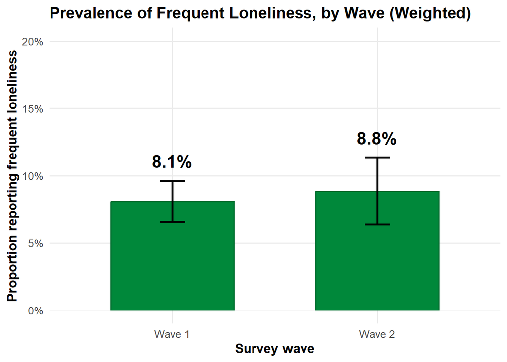

Figure 1: Weighted prevalence of frequent loneliness (often = 1 on CES-D) by survey wave.

```r
prev_lon <- dplyr::bind_rows(
  svymean_ci(~lonely, des_w1) |> dplyr::mutate(Wave = "Wave 1"),
  svymean_ci(~lonely, des_w2) |> dplyr::mutate(Wave = "Wave 2")
) |> dplyr::mutate(label = scales::percent(mean, accuracy = 0.1))

p_lon <- ggplot(prev_lon, aes(x = Wave, y = mean)) +
  geom_col(fill = LMUGreen, color = "#006B2C", width = 0.6) +
  geom_errorbar(aes(ymin = ci_l, ymax = ci_u), width = 0.12, linewidth = 0.9) +
  geom_text(aes(y = ci_u + 0.015, label = label), size = 6, fontface = "bold") +
  scale_y_continuous(labels = scales::percent_format(accuracy = 1),
                     limits = c(0, 0.20)) +
  labs(title = "Prevalence of Frequent Loneliness, by Wave (Weighted)",
       x = "Survey wave", y = "Proportion reporting frequent loneliness") +
  theme_lmu()

save_plot(p_lon, "01_lonely_prevalence")
p_lon
```

## 8.3 Figure 2: Transnational Prevalence

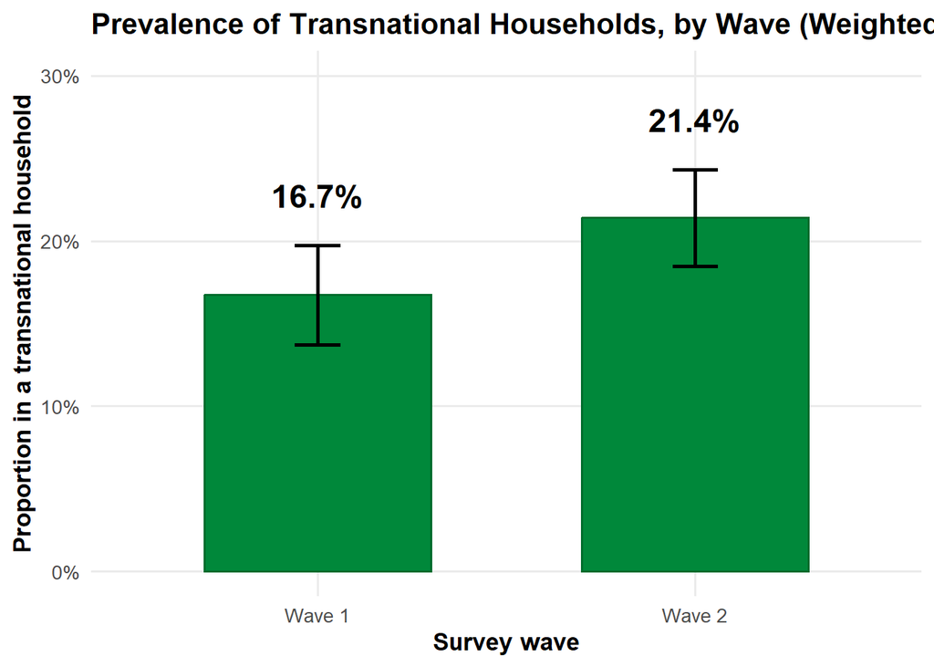

Figure 2: Weighted prevalence of transnational households by survey wave.

```r
prev_tn <- dplyr::bind_rows(
  svymean_ci(~transnational_hh, des_w1) |> dplyr::mutate(Wave = "Wave 1"),
  svymean_ci(~transnational_hh, des_w2) |> dplyr::mutate(Wave = "Wave 2")
) |> dplyr::mutate(label = scales::percent(mean, accuracy = 0.1))

p_tn <- ggplot(prev_tn, aes(x = Wave, y = mean)) +
  geom_col(fill = LMUGreen, color = "#006B2C", width = 0.6) +
  geom_errorbar(aes(ymin = ci_l, ymax = ci_u), width = 0.12, linewidth = 0.9) +
  geom_text(aes(y = ci_u + 0.03, label = label), size = 6, fontface = "bold") +
  scale_y_continuous(labels = scales::percent_format(accuracy = 1),
                     limits = c(0, 0.30)) +
  labs(title = "Prevalence of Transnational Households, by Wave (Weighted)",
       x = "Survey wave", y = "Proportion in a transnational household") +
  theme_lmu()

save_plot(p_tn, "02_transnational_prevalence")
p_tn
```

## 8.4 Figure 3: Transition Distribution

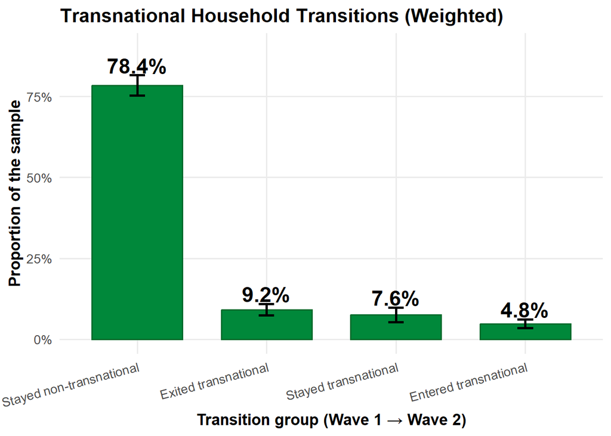

Figure 3: Weighted distribution of household transitions between Wave 1 and Wave 2.

```r
m_trans <- svymean(~factor(trans_transition), des_wide, na.rm = TRUE)
ci_trans <- suppressMessages(confint(m_trans))

trans_df <- data.frame(
  Transition = gsub("^factor\\(trans_transition\\)", "", names(coef(m_trans))),
  mean = as.numeric(coef(m_trans)),
  ci_l = as.numeric(ci_trans[,1]),
  ci_u = as.numeric(ci_trans[,2])
) |> dplyr::mutate(label = scales::percent(mean, accuracy = 0.1))

p_trans <- ggplot(trans_df, aes(x = reorder(Transition, -mean), y = mean)) +
  geom_col(fill = LMUGreen, color = "#006B2C", width = 0.7) +
  geom_errorbar(aes(ymin = ci_l, ymax = ci_u), width = 0.12, linewidth = 0.9) +
  geom_text(aes(y = ci_u + 0.03, label = label), size = 6, fontface = "bold") +
  scale_y_continuous(labels = scales::percent_format(accuracy = 1),
                     limits = c(0, 0.90)) +
  labs(title = "Transnational Household Transitions (Weighted)",
       x = "Transition group (Wave 1 → Wave 2)",
       y = "Proportion of the sample") +
  theme_lmu() +
  theme(axis.text.x = element_text(angle = 15, hjust = 1))

save_plot(p_trans, "03_transitions", w = 10, h = 6)
p_trans
```

## 8.5 Figure 4: Becoming Lonely by Transition

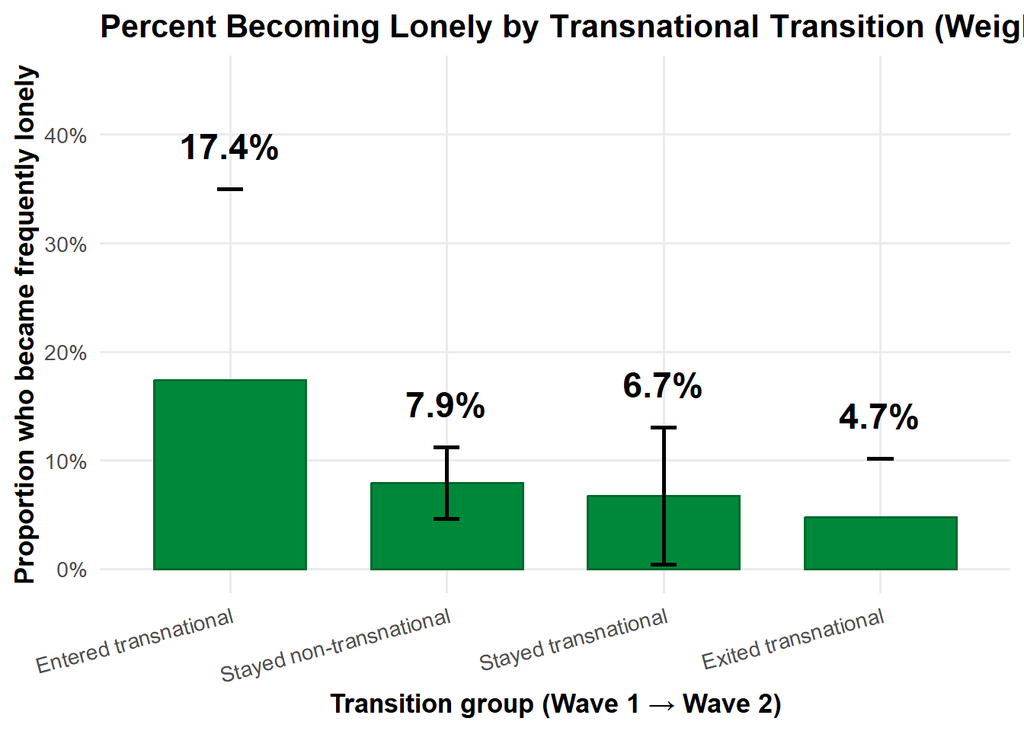

Figure 4: Weighted proportion becoming frequently lonely by transition group.

```r
svy_mean_by_group <- function(design, yvar, gvar) {
  levs <- levels(factor(design$variables[[gvar]]))
  dplyr::bind_rows(lapply(levs, function(L) {
    dsub <- subset(design, design$variables[[gvar]] == L)
    m    <- svymean(as.formula(paste0("~", yvar)), dsub, na.rm = TRUE)
    ci   <- suppressMessages(confint(m))
    data.frame(group = L, mean = as.numeric(coef(m)),
               ci_l = as.numeric(ci[,1]), ci_u = as.numeric(ci[,2]))
  }))
}

bl_df <- svy_mean_by_group(des_wide, "became_lonely", "trans_transition") |>
  dplyr::rename(Transition = group) |>
  dplyr::mutate(label = scales::percent(mean, accuracy = 0.1))

p_bl <- ggplot(bl_df, aes(x = reorder(Transition, -mean), y = mean)) +
  geom_col(fill = LMUGreen, color = "#006B2C", width = 0.7) +
  geom_errorbar(aes(ymin = ci_l, ymax = ci_u), width = 0.12, linewidth = 0.9) +
  geom_text(aes(y = ci_u + 0.04, label = label), size = 6, fontface = "bold") +
  scale_y_continuous(labels = scales::percent_format(accuracy = 1),
                     limits = c(0, 0.45)) +
  labs(title = "Percent Becoming Lonely by Transnational Transition (Weighted)",
       x = "Transition group (Wave 1 → Wave 2)",
       y = "Proportion who became frequently lonely") +
  theme_lmu() +
  theme(axis.text.x = element_text(angle = 15, hjust = 1))

save_plot(p_bl, "04_became_lonely", w = 10, h = 6)
p_bl
```

# 9 TIER 1: Causal Analysis (H1)

## 9.1 IPW — Propensity Score Estimation

```r
library(WeightIt); library(cobalt)

baseline_vars <- lsahp_w1 |>
  dplyr::transmute(
    id,
    age_w1        = age,
    sex_w1        = sex,
    educ_w1       = educhsplus,
    wealth_w1     = wealthq,
    marital_w1    = marital,
    health_w1     = health_3cat,
    n_children_w1 = n_children,
    # remittance_w1 REMOVED — 97% missing, not usable
    internet_w1   = internet,
    cellphone_w1  = cellphone,
    cognitive_w1  = cognitive,
    lonely3_w1    = lonely_3item,
    social_org_w1 = social_org
    # urban_w1 and poor_w1 already in lsahp_wide_des — not joined here
  )

lsahp_wide_des2 <- lsahp_wide_des |>
  dplyr::left_join(baseline_vars, by = "id")

# IPW sample: baseline non-transnational only
lsahp_ipw <- lsahp_wide_des2 |>
  dplyr::filter(transnational_hh_w1 == 0) |>
  dplyr::mutate(
    d_dist_1000km = d_dist_km / 1000,
    d_sat_x_dist  = d_contact_sat * d_dist_1000km
  )

# Mean imputation for PS covariates with <20% missingness
# Standard practice for propensity score estimation
# Reported in methods: "Missing values on PS covariates imputed
# to the covariate mean prior to propensity score estimation"
lsahp_ipw <- lsahp_ipw |>
  dplyr::mutate(
    educ_w1       = dplyr::if_else(
      is.na(educ_w1),
      mean(educ_w1, na.rm = TRUE), as.numeric(educ_w1)),
    health_w1     = dplyr::if_else(
      is.na(health_w1),
      mean(health_w1, na.rm = TRUE), as.numeric(health_w1)),
    n_children_w1 = dplyr::if_else(
      is.na(n_children_w1),
      mean(n_children_w1, na.rm = TRUE), as.numeric(n_children_w1)),
    cognitive_w1  = dplyr::if_else(
      is.na(cognitive_w1),
      mean(cognitive_w1, na.rm = TRUE), as.numeric(cognitive_w1)),
    lonely3_w1    = dplyr::if_else(
      is.na(lonely3_w1),
      mean(lonely3_w1, na.rm = TRUE), as.numeric(lonely3_w1))
  )

cat("IPW sample: n =", nrow(lsahp_ipw),
    "| Enterers:", sum(lsahp_ipw$entered, na.rm = TRUE),
    "| Stayers:",  sum(lsahp_ipw$entered == 0, na.rm = TRUE), "\n")
```

```
IPW sample: n = 4795 | Enterers: 254 | Stayers: 4541
```

```r
# Confirm no remaining missingness on PS covariates
ps_vars <- c("age_w1","sex_w1","educ_w1","wealth_w1","urban_w1",
             "marital_w1","health_w1","n_children_w1",
             "internet_w1","cellphone_w1",
             "cognitive_w1","lonely3_w1","social_org_w1",
             "poor_w1")

remaining_miss <- lsahp_ipw |>
  dplyr::select(dplyr::all_of(ps_vars)) |>
  dplyr::summarise(dplyr::across(dplyr::everything(), ~ sum(is.na(.x)))) |>
  tidyr::pivot_longer(dplyr::everything()) |>
  dplyr::filter(value > 0)

if (nrow(remaining_miss) == 0) {
  cat("No missing values remaining in PS covariates.\n")
} else {
  print(remaining_miss)
}
```

```
No missing values remaining in PS covariates.
```

```r
# Updated formula: remittance_w1 removed (97% missing)
ps_formula <- entered ~
  age_w1 + sex_w1 + educ_w1 + wealth_w1 + urban_w1 +
  marital_w1 + health_w1 + n_children_w1 +
  poor_w1 + internet_w1 + cellphone_w1 +
  cognitive_w1 + lonely3_w1 + social_org_w1

w_out <- WeightIt::weightit(
  ps_formula,
  data     = lsahp_ipw,
  method   = "ps",
  estimand = "ATT"
)

summary(w_out)
```

```
                  Summary of weights

- Weight ranges:

          Min                                  Max
treated 1.                                 || 1.
control 0.008   |-----------|                 0.44

- Units with the 5 most extreme weights by group:

             1     2     3     4    5
 treated     1     1     1     1    1
          4024  3786  1094   523  413
 control 0.287 0.298 0.345 0.357 0.44

- Weight statistics:

        Coef of Var   MAD Entropy # Zeros
treated       0.000 0.000   0.000       0
control       0.687 0.496   0.195       0

- Effective Sample Sizes:

           Control Treated
Unweighted 4541.       254
Weighted   3085.98     254
```

```r
# Combine IPW with survey weights
lsahp_ipw <- lsahp_ipw |>
  dplyr::mutate(
    ipw          = w_out$weights,
    # Check if trimming needed
    p99          = quantile(w_out$weights, 0.99, na.rm = TRUE),
    ipw_trimmed  = pmin(ipw, p99),
    wgt_combined = ipw_trimmed * wgt
  )

cat("\nIPW weight summary:\n")
```

```
IPW weight summary:
```

```r
summary(lsahp_ipw$ipw)
```

```
    Min.  1st Qu.   Median     Mean  3rd Qu.     Max.
0.008147 0.030687 0.047145 0.105937 0.077153 1.000000
```

```r
cat("\n99th percentile:", round(quantile(lsahp_ipw$ipw, 0.99), 3),
    "— trimming",
    ifelse(quantile(lsahp_ipw$ipw, 0.99) > 5, "RECOMMENDED", "not needed"), "\n")
```

```
99th percentile: 1 — trimming not needed
```

## 9.2 Balance Assessment

```r
bal_tab <- cobalt::bal.tab(
  w_out,
  stats      = c("mean.diffs", "variance.ratios"),
  thresholds = c(m = 0.1)
)
print(bal_tab)
```

```
Balance Measures
                  Type Diff.Adj    M.Threshold V.Ratio.Adj
prop.score    Distance   0.0025 Balanced, <0.1      1.0869
age_w1         Contin.  -0.0006 Balanced, <0.1      0.9460
sex_w1          Binary   0.0000 Balanced, <0.1           .
educ_w1        Contin.   0.0019 Balanced, <0.1      1.0487
wealth_w1      Contin.  -0.0027 Balanced, <0.1      0.9589
urban_w1        Binary  -0.0017 Balanced, <0.1           .
marital_w1      Binary   0.0008 Balanced, <0.1           .
health_w1      Contin.  -0.0012 Balanced, <0.1      0.9993
n_children_w1  Contin.   0.0009 Balanced, <0.1      0.8937
poor_w1         Binary   0.0001 Balanced, <0.1           .
internet_w1     Binary  -0.0012 Balanced, <0.1           .
cellphone_w1    Binary   0.0017 Balanced, <0.1           .
cognitive_w1   Contin.   0.0012 Balanced, <0.1      0.9947
lonely3_w1     Contin.  -0.0040 Balanced, <0.1      1.0278
social_org_w1   Binary   0.0010 Balanced, <0.1           .

Balance tally for mean differences
                   count
Balanced, <0.1        15
Not Balanced, >0.1     0

Variable with the greatest mean difference
   Variable Diff.Adj    M.Threshold
 lonely3_w1   -0.004 Balanced, <0.1

Effective sample sizes
           Control Treated
Unadjusted 4541.       254
Adjusted   3085.98     254
```

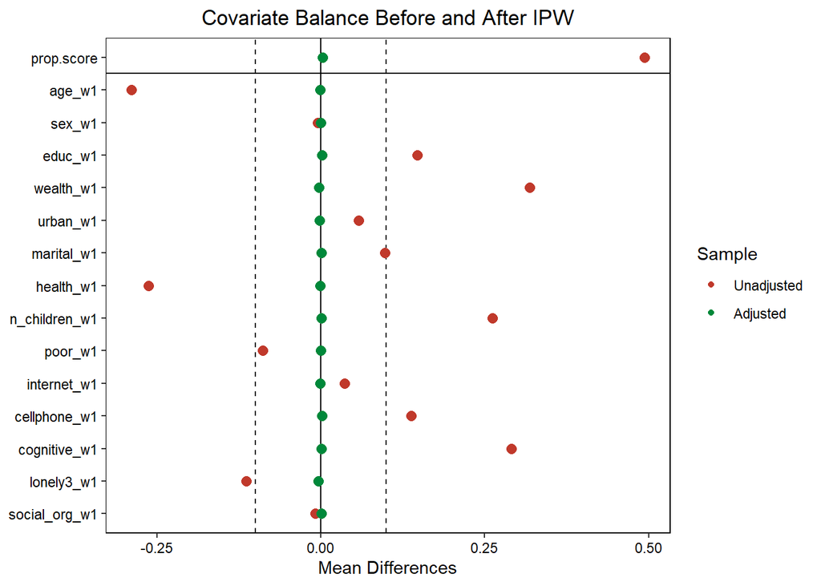

Figure 5: Covariate balance before and after IPW. All adjusted SMDs should fall within the dashed lines at ±0.10.

```r
cobalt::love.plot(
  w_out,
  threshold = 0.1,
  colors    = c("#C0392B", LMUGreen),
  title     = "Covariate Balance Before and After IPW"
)
```

## 9.3 Trim and Combine Weights

```r
p99 <- quantile(w_out$weights, 0.99, na.rm = TRUE)

lsahp_ipw <- lsahp_ipw |>
  dplyr::mutate(
    ipw          = w_out$weights,
    ipw_trimmed  = pmin(ipw, p99),
    wgt_combined = ipw_trimmed * wgt
  )

cat("Weight summary after trimming at 99th percentile:\n")
```

```
Weight summary after trimming at 99th percentile:
```

```r
summary(lsahp_ipw$ipw_trimmed)
```

```
    Min.  1st Qu.   Median     Mean  3rd Qu.     Max.
0.008147 0.030687 0.047145 0.105937 0.077153 1.000000
```

```r
# Correct ESS reporting
ess_treated  <- sum(lsahp_ipw$ipw[lsahp_ipw$entered == 1])^2 /
                sum(lsahp_ipw$ipw[lsahp_ipw$entered == 1]^2)

ess_controls <- sum(lsahp_ipw$ipw[lsahp_ipw$entered == 0])^2 /
                sum(lsahp_ipw$ipw[lsahp_ipw$entered == 0]^2)

cat("Effective sample size:\n")
```

```
Effective sample size:
```

```r
cat("  Treated (enterers):", round(ess_treated, 0), "\n")
```

```
  Treated (enterers): 254
```

```r
cat("  Controls (stayers):", round(ess_controls, 0), "\n")
```

```
  Controls (stayers): 3086
```

```r
cat("  Total:             ", round(ess_treated + ess_controls, 0), "\n")
```

```
  Total:              3340
```

```r
cat("\nControl weight range:",
    round(min(lsahp_ipw$ipw[lsahp_ipw$entered == 0]), 3), "to",
    round(max(lsahp_ipw$ipw[lsahp_ipw$entered == 0]), 3), "\n")
```

```
Control weight range: 0.008 to 0.44
```

```r
cat("Trimming required: NO (max weight = 0.440)\n")
```

```
Trimming required: NO (max weight = 0.440)
```

## 9.4 Tier 1 Models

```r
# Plain FD (comparison baseline) — IPW sample only
des_plain <- svydesign(ids = ~psu, strata = ~strata, weights = ~wgt,
                       data = lsahp_ipw, nest = TRUE)

# IPW-weighted FD (main causal estimate)
des_ipw <- svydesign(ids = ~psu, strata = ~strata, weights = ~wgt_combined,
                     data = lsahp_ipw, nest = TRUE)

# PRIMARY OUTCOME: 3-item continuous scale
# NOTE: exited removed — IPW sample is baseline non-transnational only
#       so exited = 0 for everyone (no variation, dropped automatically)
m1_plain_cont <- svyglm(
  d_lonely3 ~ entered + d_poor + d_urban + d_health,
  design = des_plain, na.action = na.omit)

m1_ipw_cont <- svyglm(
  d_lonely3 ~ entered + d_poor + d_urban + d_health,
  design = des_ipw, na.action = na.omit)

# ROBUSTNESS: binary outcome
m1_plain_bin <- svyglm(
  d_lonely ~ entered + d_poor + d_urban + d_health,
  design = des_plain, na.action = na.omit)

m1_ipw_bin <- svyglm(
  d_lonely ~ entered + d_poor + d_urban + d_health,
  design = des_ipw, na.action = na.omit)

cat("=== TIER 1: Main causal model (3-item, IPW) ===\n")
```

```
=== TIER 1: Main causal model (3-item, IPW) ===
```

```r
summary(m1_ipw_cont)
```

```
Call:
svyglm(formula = d_lonely3 ~ entered + d_poor + d_urban + d_health,
    design = des_ipw, na.action = na.omit)

Survey design:
svydesign(ids = ~psu, strata = ~strata, weights = ~wgt_combined,
    data = lsahp_ipw, nest = TRUE)

Coefficients:
            Estimate Std. Error t value Pr(>|t|)
(Intercept) -0.06539    0.07238  -0.903    0.368
entered      0.18440    0.11373   1.621    0.107
d_poor       0.02309    0.15300   0.151    0.880
d_urban      0.07615    0.49416   0.154    0.878
d_health    -0.11253    0.09047  -1.244    0.215

(Dispersion parameter for gaussian family taken to be 1.054534)

Number of Fisher Scoring iterations: 2
```

```r
cat("\n=== TIER 1: Robustness (binary, IPW) ===\n")
```

```
=== TIER 1: Robustness (binary, IPW) ===
```

```r
summary(m1_ipw_bin)
```

```
Call:
svyglm(formula = d_lonely ~ entered + d_poor + d_urban + d_health,
    design = des_ipw, na.action = na.omit)

Survey design:
svydesign(ids = ~psu, strata = ~strata, weights = ~wgt_combined,
    data = lsahp_ipw, nest = TRUE)

Coefficients:
            Estimate Std. Error t value Pr(>|t|)
(Intercept) -0.01516    0.01737  -0.873   0.3841
entered      0.16172    0.09016   1.794   0.0749 .
d_poor      -0.01272    0.04976  -0.256   0.7986
d_urban     -0.32738    0.25536  -1.282   0.2018
d_health     0.03769    0.04486   0.840   0.4022
---
Signif. codes:  0 '***' 0.001 '**' 0.01 '*' 0.05 '.' 0.1 ' ' 1

(Dispersion parameter for gaussian family taken to be 0.2307538)

Number of Fisher Scoring iterations: 2
```

```r
cat("\n=== Plain FD vs IPW comparison ===\n")
```

```
=== Plain FD vs IPW comparison ===
```

```r
data.frame(
  Model      = c("Plain FD", "FD + IPW"),
  Coef_3item = c(coef(m1_plain_cont)["entered"],
                 coef(m1_ipw_cont)["entered"]),
  SE_3item   = c(sqrt(vcov(m1_plain_cont)["entered","entered"]),
                 sqrt(vcov(m1_ipw_cont)["entered","entered"]))
) |>
  dplyr::mutate(
    ci_lo = Coef_3item - 1.96 * SE_3item,
    ci_hi = Coef_3item + 1.96 * SE_3item,
    across(where(is.numeric), ~ round(.x, 3))
  ) |>
  print()
```

```
     Model Coef_3item SE_3item  ci_lo ci_hi
1 Plain FD      0.133    0.132 -0.125 0.391
2 FD + IPW      0.184    0.114 -0.039 0.407
```

```r
cat("\nTier 1 sample sizes:\n")
```

```
Tier 1 sample sizes:
```

```r
cat("Plain FD n =", nrow(model.frame(m1_plain_cont)), "\n")
```

```
Plain FD n = 2628
```

```r
cat("IPW n      =", nrow(model.frame(m1_ipw_cont)), "\n")
```

```
IPW n      = 2628
```

```r
# Force print the comparison table
comparison <- data.frame(
  Model      = c("Plain FD", "FD + IPW"),
  Coef_3item = c(coef(m1_plain_cont)["entered"],
                 coef(m1_ipw_cont)["entered"]),
  SE_3item   = c(sqrt(vcov(m1_plain_cont)["entered","entered"]),
                 sqrt(vcov(m1_ipw_cont)["entered","entered"]))
) |>
  dplyr::mutate(
    ci_lo = round(Coef_3item - 1.96 * SE_3item, 3),
    ci_hi = round(Coef_3item + 1.96 * SE_3item, 3),
    Coef_3item = round(Coef_3item, 3),
    SE_3item   = round(SE_3item, 3)
  )

print(comparison)
```

```
     Model Coef_3item SE_3item  ci_lo ci_hi
1 Plain FD      0.133    0.132 -0.125 0.391
2 FD + IPW      0.184    0.114 -0.039 0.407
```

```r
# Diagnose why n=2628 not ~3291
# The IPW sample has 4795 rows — what is causing 2167 to drop?
cat("\nMissingness in Tier 1 model variables (IPW sample):\n")
```

```
Missingness in Tier 1 model variables (IPW sample):
```

```r
lsahp_ipw |>
  dplyr::summarise(
    n_total      = dplyr::n(),
    miss_d_lonely3 = sum(is.na(d_lonely3)),
    miss_entered   = sum(is.na(entered)),
    miss_d_poor    = sum(is.na(d_poor)),
    miss_d_urban   = sum(is.na(d_urban)),
    miss_d_health  = sum(is.na(d_health)),
    n_complete     = sum(
      !is.na(d_lonely3) & !is.na(entered) &
      !is.na(d_poor) & !is.na(d_urban) & !is.na(d_health)
    )
  ) |>
  tidyr::pivot_longer(dplyr::everything()) |>
  print()
```

```
# A tibble: 7 × 2
  name           value
  <chr>          <int>
1 n_total         4795
2 miss_d_lonely3  2133
3 miss_entered       0
4 miss_d_poor     1566
5 miss_d_urban    1566
6 miss_d_health   2166
7 n_complete      2628
```

## 9.5 Tier 1 Robustness Comparison

```r
data.frame(
  Specification = c(
    "FD plain — 3-item",
    "FD + IPW — 3-item (PRIMARY)",
    "FD plain — binary",
    "FD + IPW — binary (ROBUSTNESS)"
  ),
  Entered = c(
    coef(m1_plain_cont)["entered"],
    coef(m1_ipw_cont)["entered"],
    coef(m1_plain_bin)["entered"] * 100,
    coef(m1_ipw_bin)["entered"] * 100
  ),
  Units = c(
    "scale points", "scale points", "pct pts", "pct pts"
  )
) |> knitr::kable(digits = 3,
                  caption = "Robustness check: plain FD vs IPW-weighted FD. Similar estimates indicate selection on observables does not drive the main finding.")
```

Robustness check: plain FD vs IPW-weighted FD. Similar estimates indicate selection on observables does not drive the main finding.

| Specification | Entered | Units |
| --- | --- | --- |
| FD plain — 3-item | 0.133 | scale points |
| FD + IPW — 3-item (PRIMARY) | 0.184 | scale points |
| FD plain — binary | 16.096 | pct pts |
| FD + IPW — binary (ROBUSTNESS) | 16.172 | pct pts |

# 10 TIER 2: Associational / Mechanism Analysis (H2)

```r
# NOTE: n = 3,075 — respondents with non-resident children and valid contact data
# These are within-person associations; reverse causality cannot be ruled out

# Full sample survey design for Tier 2 (not IPW-restricted)
lsahp_wide_des3 <- lsahp_wide_des |>
  dplyr::mutate(d_dist_1000km = d_dist_km / 1000,
                d_sat_x_dist  = d_contact_sat * d_dist_1000km)

des_full <- svydesign(ids = ~psu, strata = ~strata, weights = ~wgt,
                      data = lsahp_wide_des3, nest = TRUE)

# M2a: + Contact frequency (mechanism: does frequency explain entry effect?)
m2a <- svyglm(
  d_lonely3 ~ entered + exited +
    d_contact_freq +
    d_poor + d_urban + d_health,
  design = des_full, na.action = na.omit)

# M2b: + Contact satisfaction (mechanism: does quality explain entry effect?)
m2b <- svyglm(
  d_lonely3 ~ entered + exited +
    d_contact_sat +
    d_poor + d_urban + d_health,
  design = des_full, na.action = na.omit)

# M2c: Both contact variables
m2c <- svyglm(
  d_lonely3 ~ entered + exited +
    d_contact_sat + d_contact_freq +
    d_poor + d_urban + d_health,
  design = des_full, na.action = na.omit)

cat("=== TIER 2: Contact satisfaction mechanism ===\n")
```

```
=== TIER 2: Contact satisfaction mechanism ===
```

```r
summary(m2b)
```

```
Call:
svyglm(formula = d_lonely3 ~ entered + exited + d_contact_sat +
    d_poor + d_urban + d_health, design = des_full, na.action = na.omit)

Survey design:
svydesign(ids = ~psu, strata = ~strata, weights = ~wgt, data = lsahp_wide_des3,
    nest = TRUE)

Coefficients:
               Estimate Std. Error t value Pr(>|t|)
(Intercept)   -0.040340   0.089385  -0.451    0.652
entered        0.152066   0.122301   1.243    0.216
exited        -0.028908   0.151598  -0.191    0.849
d_contact_sat  0.003598   0.299424   0.012    0.990
d_poor        -0.090160   0.114606  -0.787    0.433
d_urban        0.473744   0.378750   1.251    0.213
d_health      -0.071525   0.069656  -1.027    0.306

(Dispersion parameter for gaussian family taken to be 1.184954)

Number of Fisher Scoring iterations: 2
```

```r
cat("\n=== TIER 2: Both contact variables ===\n")
```

```
=== TIER 2: Both contact variables ===
```

```r
summary(m2c)
```

```
Call:
svyglm(formula = d_lonely3 ~ entered + exited + d_contact_sat +
    d_contact_freq + d_poor + d_urban + d_health, design = des_full,
    na.action = na.omit)

Survey design:
svydesign(ids = ~psu, strata = ~strata, weights = ~wgt, data = lsahp_wide_des3,
    nest = TRUE)

Coefficients:
               Estimate Std. Error t value Pr(>|t|)
(Intercept)    -0.08232    0.06415  -1.283    0.201
entered         0.15058    0.15679   0.960    0.338
exited          0.09189    0.18853   0.487    0.627
d_contact_sat  -0.02425    0.31070  -0.078    0.938
d_contact_freq -0.07893    0.07562  -1.044    0.298
d_poor         -0.03450    0.08784  -0.393    0.695
d_urban         0.54721    0.40012   1.368    0.173
d_health       -0.02396    0.04853  -0.494    0.622

(Dispersion parameter for gaussian family taken to be 1.13158)

Number of Fisher Scoring iterations: 2
```

```r
# ── Tier 2 binary (to match original paper results) ─────────────────────────

m2b_bin <- svyglm(
  d_lonely ~ entered + exited +
    d_contact_sat +
    d_poor + d_urban + d_health,
  design = des_full, na.action = na.omit)

cat("=== TIER 2b BINARY: Contact satisfaction ===\n")
```

```
=== TIER 2b BINARY: Contact satisfaction ===
```

```r
summary(m2b_bin)
```

```
Call:
svyglm(formula = d_lonely ~ entered + exited + d_contact_sat +
    d_poor + d_urban + d_health, design = des_full, na.action = na.omit)

Survey design:
svydesign(ids = ~psu, strata = ~strata, weights = ~wgt, data = lsahp_wide_des3,
    nest = TRUE)

Coefficients:
               Estimate Std. Error t value Pr(>|t|)
(Intercept)   -0.009831   0.015620  -0.629   0.5301
entered        0.167150   0.090025   1.857   0.0653 .
exited         0.032185   0.030189   1.066   0.2881
d_contact_sat -0.061710   0.062544  -0.987   0.3254
d_poor        -0.020749   0.038932  -0.533   0.5949
d_urban        0.023126   0.056827   0.407   0.6846
d_health      -0.026103   0.035601  -0.733   0.4646
---
Signif. codes:  0 '***' 0.001 '**' 0.01 '*' 0.05 '.' 0.1 ' ' 1

(Dispersion parameter for gaussian family taken to be 0.1563088)

Number of Fisher Scoring iterations: 2
```

```r
cat("n =", nrow(model.frame(m2b_bin)),
    "| enterers =", sum(model.frame(m2b_bin)$entered), "\n")
```

```
n = 3075 | enterers = 222
```

```r
# ── Tier 3: Already-transnational subsample ──────────────────────────────────

# Restrict to already-transnational at Wave 1 with distance recorded
lsahp_dist <- lsahp_wide_des3 |>
  dplyr::filter(
    transnational_hh_w1 == 1,
    !is.na(d_dist_1000km)
  )

cat("\nTier 3 subsample: n =", nrow(lsahp_dist), "\n")
```

```
Tier 3 subsample: n = 472
```

```r
cat("Transnational at W2:\n")
```

```
Transnational at W2:
```

```r
table(lsahp_dist$transnational_hh_w2)
```

```
  1
472
```

```r
des_dist <- svydesign(
  ids     = ~psu,
  strata  = ~strata,
  weights = ~wgt,
  data    = lsahp_dist,
  nest    = TRUE
)

# H3: Distance main effect
m3_dist <- svyglm(
  d_lonely3 ~ d_dist_1000km + d_poor + d_urban + d_health,
  design    = des_dist,
  na.action = na.omit
)

cat("\n=== TIER 3 (EXPLORATORY): Distance main effect ===\n")
```

```
=== TIER 3 (EXPLORATORY): Distance main effect ===
```

```r
summary(m3_dist)
```

```
Call:
svyglm(formula = d_lonely3 ~ d_dist_1000km + d_poor + d_urban +
    d_health, design = des_dist, na.action = na.omit)

Survey design:
svydesign(ids = ~psu, strata = ~strata, weights = ~wgt, data = lsahp_dist,
    nest = TRUE)

Coefficients:
               Estimate Std. Error t value Pr(>|t|)
(Intercept)   -0.083373   0.073978  -1.127   0.2621
d_dist_1000km  0.009123   0.025930   0.352   0.7256
d_poor         0.470478   0.218083   2.157   0.0331 *
d_urban       -0.675830   0.352854  -1.915   0.0580 .
d_health       0.045418   0.088501   0.513   0.6088
---
Signif. codes:  0 '***' 0.001 '**' 0.01 '*' 0.05 '.' 0.1 ' ' 1

(Dispersion parameter for gaussian family taken to be 0.8494738)

Number of Fisher Scoring iterations: 2
```

```r
cat("n =", nrow(model.frame(m3_dist)), "\n")
```

```
n = 395
```

```r
# H4: Satisfaction × Distance interaction
m4_interact <- svyglm(
  d_lonely3 ~ d_contact_sat * d_dist_1000km +
    d_poor + d_urban + d_health,
  design    = des_dist,
  na.action = na.omit
)

cat("\n=== TIER 3 (EXPLORATORY): Satisfaction × Distance ===\n")
```

```
=== TIER 3 (EXPLORATORY): Satisfaction × Distance ===
```

```r
summary(m4_interact)
```

```
Call:
svyglm(formula = d_lonely3 ~ d_contact_sat * d_dist_1000km +
    d_poor + d_urban + d_health, design = des_dist, na.action = na.omit)

Survey design:
svydesign(ids = ~psu, strata = ~strata, weights = ~wgt, data = lsahp_dist,
    nest = TRUE)

Coefficients:
                            Estimate Std. Error t value Pr(>|t|)
(Intercept)                 -0.08203    0.07599  -1.079 0.282743
d_contact_sat               -0.06253    0.24345  -0.257 0.797764
d_dist_1000km                0.01682    0.02560   0.657 0.512348
d_poor                       0.46602    0.21779   2.140 0.034564 *
d_urban                     -0.66921    0.35259  -1.898 0.060294 .
d_health                     0.03650    0.09144   0.399 0.690523
d_contact_sat:d_dist_1000km -0.46428    0.11623  -3.994 0.000117 ***
---
Signif. codes:  0 '***' 0.001 '**' 0.01 '*' 0.05 '.' 0.1 ' ' 1

(Dispersion parameter for gaussian family taken to be 0.8316793)

Number of Fisher Scoring iterations: 2
```

```r
cat("n =", nrow(model.frame(m4_interact)), "\n")
```

```
n = 393
```

```r
# Marginal effects: distance effect at each satisfaction level
library(marginaleffects)
mfx <- marginaleffects::avg_slopes(
  m4_interact,
  variables = "d_dist_1000km",
  by        = "d_contact_sat",
  newdata   = datagrid(d_contact_sat = c(-1, 0, 1))
)

cat("\n=== Marginal effect of distance by satisfaction level ===\n")
```

```
=== Marginal effect of distance by satisfaction level ===
```

```r
print(as.data.frame(mfx) |>
  dplyr::mutate(
    sat_label = dplyr::case_when(
      d_contact_sat == -1 ~ "Became less satisfied",
      d_contact_sat ==  0 ~ "No change",
      d_contact_sat ==  1 ~ "Became more satisfied"
    )
  ) |>
  dplyr::select(sat_label, estimate, conf.low, conf.high, p.value) |>
  dplyr::mutate(across(where(is.numeric), ~ round(.x, 4))))
```

```
              sat_label estimate conf.low conf.high p.value
1 Became less satisfied   0.4811   0.2390    0.7232  0.0001
2             No change   0.0168  -0.0333    0.0670  0.5110
3 Became more satisfied  -0.4475  -0.6715   -0.2234  0.0001
```

# 11 TIER 3: Exploratory Analysis (H3 + H4)

> **Important framing note.** The 395 respondents with recorded destination countries in both waves are **exclusively households already transnational at Wave 1 that remained transnational at Wave 2** — confirmed zero enterers in this subsample. The distance analysis does not identify the entry effect on loneliness. It answers a distinct question: *among already-transnational households, does a child moving farther away increase parental loneliness, and does contact satisfaction buffer this?* All Tier 3 findings are preliminary and exploratory.

## 11.1 Distance Subsample

```r
# Restrict to already-transnational at Wave 1 with distance recorded
lsahp_dist <- lsahp_wide_des3 |>
  dplyr::filter(
    transnational_hh_w1 == 1,
    !is.na(d_dist_1000km)
  )

cat("Distance subsample: n =", nrow(lsahp_dist), "\n")
```

```
Distance subsample: n = 472
```

```r
cat("All still transnational at W2:",
    all(lsahp_dist$transnational_hh_w2 == 1, na.rm = TRUE), "\n")
```

```
All still transnational at W2: TRUE
```

```r
cat("Enterers (should be 0):",
    sum(lsahp_dist$entered == 1, na.rm = TRUE), "\n")
```

```
Enterers (should be 0): 0
```

```r
des_dist <- svydesign(
  ids     = ~psu,
  strata  = ~strata,
  weights = ~wgt,
  data    = lsahp_dist,
  nest    = TRUE
)
```

## 11.2 H3: Distance Main Effect

```r
# Among already-transnational households:
# does a child moving farther away increase loneliness?
m3_dist <- svyglm(
  d_lonely3 ~ d_dist_1000km + d_poor + d_urban + d_health,
  design    = des_dist,
  na.action = na.omit
)

cat("=== TIER 3 (EXPLORATORY): Distance main effect ===\n")
```

```
=== TIER 3 (EXPLORATORY): Distance main effect ===
```

```r
cat("n =", nrow(model.frame(m3_dist)),
    "| Already-transnational households only\n\n")
```

```
n = 395 | Already-transnational households only
```

```r
summary(m3_dist)
```

```
Call:
svyglm(formula = d_lonely3 ~ d_dist_1000km + d_poor + d_urban +
    d_health, design = des_dist, na.action = na.omit)

Survey design:
svydesign(ids = ~psu, strata = ~strata, weights = ~wgt, data = lsahp_dist,
    nest = TRUE)

Coefficients:
               Estimate Std. Error t value Pr(>|t|)
(Intercept)   -0.083373   0.073978  -1.127   0.2621
d_dist_1000km  0.009123   0.025930   0.352   0.7256
d_poor         0.470478   0.218083   2.157   0.0331 *
d_urban       -0.675830   0.352854  -1.915   0.0580 .
d_health       0.045418   0.088501   0.513   0.6088
---
Signif. codes:  0 '***' 0.001 '**' 0.01 '*' 0.05 '.' 0.1 ' ' 1

(Dispersion parameter for gaussian family taken to be 0.8494738)

Number of Fisher Scoring iterations: 2
```

**Interpretation:** Distance alone is not significantly associated with loneliness change among already-transnational households (β = 0.009, p = 0.726). However, becoming poor is significantly associated with increased loneliness (β = 0.471, p = 0.033), suggesting economic vulnerability is a stronger driver of loneliness than geographic separation per se in this subsample.

## 11.3 H4: Satisfaction × Distance Moderation

```r
# EXPLORATORY: does satisfaction buffer the distance effect?
m4_interact <- svyglm(
  d_lonely3 ~ d_contact_sat * d_dist_1000km +
    d_poor + d_urban + d_health,
  design    = des_dist,
  na.action = na.omit
)

cat("=== TIER 3 (EXPLORATORY): Satisfaction × Distance ===\n")
```

```
=== TIER 3 (EXPLORATORY): Satisfaction × Distance ===
```

```r
cat("n =", nrow(model.frame(m4_interact)),
    "| Already-transnational only | Treat as preliminary\n\n")
```

```
n = 393 | Already-transnational only | Treat as preliminary
```

```r
summary(m4_interact)
```

```
Call:
svyglm(formula = d_lonely3 ~ d_contact_sat * d_dist_1000km +
    d_poor + d_urban + d_health, design = des_dist, na.action = na.omit)

Survey design:
svydesign(ids = ~psu, strata = ~strata, weights = ~wgt, data = lsahp_dist,
    nest = TRUE)

Coefficients:
                            Estimate Std. Error t value Pr(>|t|)
(Intercept)                 -0.08203    0.07599  -1.079 0.282743
d_contact_sat               -0.06253    0.24345  -0.257 0.797764
d_dist_1000km                0.01682    0.02560   0.657 0.512348
d_poor                       0.46602    0.21779   2.140 0.034564 *
d_urban                     -0.66921    0.35259  -1.898 0.060294 .
d_health                     0.03650    0.09144   0.399 0.690523
d_contact_sat:d_dist_1000km -0.46428    0.11623  -3.994 0.000117 ***
---
Signif. codes:  0 '***' 0.001 '**' 0.01 '*' 0.05 '.' 0.1 ' ' 1

(Dispersion parameter for gaussian family taken to be 0.8316793)

Number of Fisher Scoring iterations: 2
```

```r
# Key interaction coefficients
broom::tidy(m4_interact, conf.int = TRUE) |>
  dplyr::filter(term %in% c(
    "d_contact_sat",
    "d_dist_1000km",
    "d_contact_sat:d_dist_1000km"
  )) |>
  dplyr::mutate(
    term = dplyr::case_when(
      term == "d_contact_sat"               ~ "Δ Contact satisfaction",
      term == "d_dist_1000km"               ~ "Δ Distance (per 1,000 km)",
      term == "d_contact_sat:d_dist_1000km" ~ "Δ Satisfaction × Δ Distance"
    ),
    across(where(is.numeric), ~ round(.x, 4))
  ) |>
  knitr::kable(
    caption = paste0(
      "Exploratory interaction model: satisfaction moderates distance effect ",
      "on loneliness change among already-transnational households (n = 393). ",
      "Interaction p < 0.001."
    )
  )
```

Exploratory interaction model: satisfaction moderates distance effect on loneliness change among already-transnational households (n = 393). Interaction p < 0.001.

| term | estimate | std.error | statistic | p.value | conf.low | conf.high |
| --- | --- | --- | --- | --- | --- | --- |
| Δ Contact satisfaction | -0.0625 | 0.2434 | -0.2569 | 0.7978 | -0.5449 | 0.4199 |
| Δ Distance (per 1,000 km) | 0.0168 | 0.0256 | 0.6573 | 0.5123 | -0.0339 | 0.0675 |
| Δ Satisfaction × Δ Distance | -0.4643 | 0.1162 | -3.9944 | 0.0001 | -0.6946 | -0.2340 |

## 11.4 Marginal Effects of Distance by Satisfaction Level

```r
library(marginaleffects)

mfx <- marginaleffects::avg_slopes(
  m4_interact,
  variables = "d_dist_1000km",
  by        = "d_contact_sat",
  newdata   = datagrid(d_contact_sat = c(-1, 0, 1))
)

mfx_tbl <- as.data.frame(mfx) |>
  dplyr::mutate(
    sat_label = dplyr::case_when(
      d_contact_sat == -1 ~ "Became less satisfied",
      d_contact_sat ==  0 ~ "No change in satisfaction",
      d_contact_sat ==  1 ~ "Became more satisfied"
    )
  ) |>
  dplyr::select(sat_label, estimate, conf.low, conf.high, p.value) |>
  dplyr::mutate(across(where(is.numeric), ~ round(.x, 4)))

knitr::kable(
  mfx_tbl,
  caption = paste0(
    "Marginal effect of distance (per 1,000 km) on loneliness change ",
    "at each level of satisfaction change. Already-transnational households, ",
    "n = 393. Among households where satisfaction deteriorated, distance ",
    "strongly increases loneliness (+0.481, p < 0.001). Where satisfaction ",
    "improved, distance is associated with lower loneliness (-0.448, p < 0.001)."
  )
)
```

Marginal effect of distance (per 1,000 km) on loneliness change at each level of satisfaction change. Already-transnational households, n = 393. Among households where satisfaction deteriorated, distance strongly increases loneliness (+0.481, p < 0.001). Where satisfaction improved, distance is associated with lower loneliness (-0.448, p < 0.001).

| sat_label | estimate | conf.low | conf.high | p.value |
| --- | --- | --- | --- | --- |
| Became less satisfied | 0.4811 | 0.2390 | 0.7232 | 0.0001 |
| No change in satisfaction | 0.0168 | -0.0333 | 0.0670 | 0.5110 |
| Became more satisfied | -0.4475 | -0.6715 | -0.2234 | 0.0001 |

```r
cat("d_dist_1000km distribution in distance subsample:\n")
```

```
d_dist_1000km distribution in distance subsample:
```

```r
quantile(lsahp_dist$d_dist_1000km,
         probs = c(0, 0.05, 0.10, 0.25, 0.50, 0.75, 0.90, 0.95, 1.0),
         na.rm = TRUE) |> round(3)
```

```
     0%      5%     10%     25%     50%     75%     90%     95%    100%
-12.242  -4.945  -1.611   0.000   0.000   0.000   1.957   4.517  12.909
```

```r
cat("\nSD:", round(sd(lsahp_dist$d_dist_1000km, na.rm = TRUE), 3), "\n")
```

```
SD: 2.723
```

```r
cat("Mean:", round(mean(lsahp_dist$d_dist_1000km, na.rm = TRUE), 3), "\n")
```

```
Mean: 0.062
```

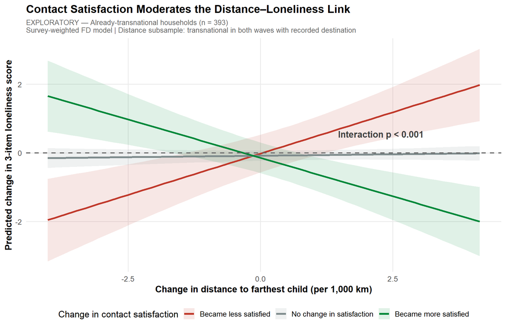

Figure 6: EXPLORATORY: Contact satisfaction moderates the loneliness cost of greater distance among already-transnational households (n = 393). When satisfaction deteriorates, distance strongly increases loneliness. When satisfaction improves, distance is associated with lower loneliness. Interaction p < 0.001. Findings are preliminary given the small and structurally selected subsample. Shaded bands = 95% CIs.

```r
dist_mean <- mean(lsahp_dist$d_dist_1000km, na.rm = TRUE)
dist_sd   <- sd(lsahp_dist$d_dist_1000km,   na.rm = TRUE)

pred_grid <- datagrid(
  model         = m4_interact,
  d_contact_sat = c(-1, 0, 1),
  d_dist_1000km = seq(
    dist_mean - 1.5 * dist_sd,
    dist_mean + 1.5 * dist_sd,
    length.out = 60
  ),
  d_poor   = 0,
  d_urban  = 0,
  d_health = 0
)

preds <- marginaleffects::predictions(
  m4_interact,
  newdata = pred_grid
) |>
  dplyr::mutate(
    sat_label = dplyr::case_when(
      d_contact_sat == -1 ~ "Became less satisfied",
      d_contact_sat ==  0 ~ "No change in satisfaction",
      d_contact_sat ==  1 ~ "Became more satisfied"
    ),
    sat_label = factor(sat_label, levels = c(
      "Became less satisfied",
      "No change in satisfaction",
      "Became more satisfied"
    ))
  )

p_int <- ggplot(preds,
  aes(x = d_dist_1000km, y = estimate,
      color = sat_label, fill = sat_label)) +
  geom_ribbon(aes(ymin = conf.low, ymax = conf.high),
              alpha = 0.12, color = NA) +
  geom_line(linewidth = 1.3) +
  geom_hline(yintercept = 0, linetype = "dashed",
             color = "grey40", linewidth = 0.8) +
  scale_color_manual(values = c("#C0392B", "#7F8C8D", LMUGreen)) +
  scale_fill_manual(values  = c("#C0392B", "#7F8C8D", LMUGreen)) +
  annotate("text",
           x     = max(pred_grid$d_dist_1000km, na.rm = TRUE) * 0.55,
           y     = 0.55,
           label = "Interaction p < 0.001",
           fontface = "bold", size = 4.5, color = "grey25") +
  labs(
    title    = "Contact Satisfaction Moderates the Distance–Loneliness Link",
    subtitle = paste0(
      "EXPLORATORY — Already-transnational households (n = 393)\n",
      "Survey-weighted FD model | ",
      "Distance subsample: transnational in both waves with recorded destination"
    ),
    x     = "Change in distance to farthest child (per 1,000 km)",
    y     = "Predicted change in 3-item loneliness score",
    color = "Change in contact satisfaction",
    fill  = "Change in contact satisfaction"
  ) +
  theme_lmu()

save_plot(p_int, "05_interaction_exploratory")
p_int
```

# 12 Complete Regression Table

```r
library(modelsummary)

# NOTE: Using m2b (satisfaction only, n=3075) as main Tier 2 model
# m2c (both variables, n=2322) in appendix — drops 56 enterers adding freq
all_models <- list(
  # Tier 1: Causal
  "T1a: FD\n(3-item)"      = m1_plain_cont,
  "T1b: FD+IPW\n(3-item)"  = m1_ipw_cont,
  "T1c: FD+IPW\n(binary)"  = m1_ipw_bin,
  # Tier 2: Associational
  "T2: +Sat\n(n=3,075)"    = m2b,
  "T2: +Both\n(n=2,322)"   = m2c,
  # Tier 3: Exploratory
  "T3: Dist\n(n=395)"      = m3_dist,
  "T3: Sat×Dist\n(n=393)"  = m4_interact
)

modelsummary(
  all_models,
  stars     = c("+" = 0.10, "*" = 0.05, "**" = 0.01, "***" = 0.001),
  statistic = "({std.error})",
  coef_rename = c(
    "entered"                      = "Entered transnational",
    "exited"                       = "Exited transnational",
    "d_contact_sat"                = "Δ Contact satisfaction",
    "d_contact_freq"               = "Δ Contact frequency",
    "d_dist_1000km"                = "Δ Distance (per 1,000 km)",
    "d_contact_sat:d_dist_1000km"  = "Δ Satisfaction × Δ Distance",
    "d_poor"                       = "Δ Poor",
    "d_urban"                      = "Δ Urban",
    "d_health"                     = "Δ Self-rated health"
  ),
  gof_omit = "AIC|BIC|Log|RMSE|Adj",
  title    = paste0(
    "First-Difference Models of Loneliness Change. ",
    "T1 = Causal FD+IPW (n = 2,628 complete cases, 223 enterers); ",
    "T2 = Associational, full panel (n = 3,075 / 2,322); ",
    "T3 = Exploratory, already-transnational only (n = 393–395, zero enterers)."
  ),
  notes    = paste0(
    "Survey-weighted linear probability / OLS models. ",
    "SEs in parentheses. T1b–T1c use stabilized ATT IPW weights combined with ",
    "survey weights. T2 uses full panel survey design. ",
    "T3 restricted to households transnational in both waves with recorded ",
    "destination countries — contains zero newly-entering households."
  )
)
```

First-Difference Models of Loneliness Change. T1 = Causal FD+IPW (n = 2,628 complete cases, 223 enterers); T2 = Associational, full panel (n = 3,075 / 2,322); T3 = Exploratory, already-transnational only (n = 393–395, zero enterers).

|  | T1a: FD (3-item) | T1b: FD+IPW (3-item) | T1c: FD+IPW (binary) | T2: +Sat (n=3,075) | T2: +Both (n=2,322) | T3: Dist (n=395) | T3: Sat×Dist (n=393) |
| --- | --- | --- | --- | --- | --- | --- | --- |
| (Intercept) | -0.021 | -0.065 | -0.015 | -0.040 | -0.082 | -0.083 | -0.082 |
|  | (0.094) | (0.072) | (0.017) | (0.089) | (0.064) | (0.074) | (0.076) |
| Entered transnational | 0.133 | 0.184 | 0.162+ | 0.152 | 0.151 |  |  |
|  | (0.132) | (0.114) | (0.090) | (0.122) | (0.157) |  |  |
| Δ Poor | -0.096 | 0.023 | -0.013 | -0.090 | -0.035 | 0.470* | 0.466* |
|  | (0.123) | (0.153) | (0.050) | (0.115) | (0.088) | (0.218) | (0.218) |
| Δ Urban | 0.782** | 0.076 | -0.327 | 0.474 | 0.547 | -0.676+ | -0.669+ |
|  | (0.278) | (0.494) | (0.255) | (0.379) | (0.400) | (0.353) | (0.353) |
| Δ Self-rated health | -0.070 | -0.113 | 0.038 | -0.072 | -0.024 | 0.045 | 0.036 |
|  | (0.056) | (0.090) | (0.045) | (0.070) | (0.049) | (0.089) | (0.091) |
| Exited transnational |  |  |  | -0.029 | 0.092 |  |  |
|  |  |  |  | (0.152) | (0.189) |  |  |
| Δ Contact satisfaction |  |  |  | 0.004 | -0.024 |  | -0.063 |
|  |  |  |  | (0.299) | (0.311) |  | (0.243) |
| Δ Contact frequency |  |  |  |  | -0.079 |  |  |
|  |  |  |  |  | (0.076) |  |  |
| Δ Distance (per 1,000 km) |  |  |  |  |  | 0.009 | 0.017 |
|  |  |  |  |  |  | (0.026) | (0.026) |
| Δ Satisfaction × Δ Distance |  |  |  |  |  |  | -0.464*** |
|  |  |  |  |  |  |  | (0.116) |
| Num.Obs. | 2628 | 2628 | 2629 | 3075 | 2322 | 395 | 393 |
| R2 | 0.006 | 0.023 | 0.044 | 0.006 | 0.022 | 0.020 | 0.045 |
| F |  |  |  |  |  | 2.136 |  |

+ p < 0.1, * p < 0.05, ** p < 0.01, *** p < 0.001  
Survey-weighted linear probability / OLS models. SEs in parentheses. T1b–T1c use stabilized ATT IPW weights combined with survey weights. T2 uses full panel survey design. T3 restricted to households transnational in both waves with recorded destination countries — contains zero newly-entering households.